# Exploring Distances

Nicolas Restrepo

12/9/2019

## Exploring distances from the prototype

```r
# Packages
library(tidyverse)
library(knitr)
library(kableExtra)
library(ggrepel)
library(gridExtra)
library(haven)
library(lavaan)
library(lme4)
library(nlme)
library(stargazer)
library(broom)
library(psych)
library(brms)
library(plotly)
library(sjPlot)
library(colorspace)

theme_set(theme_light())
```

Here, I am going to briefly explore the euclidean distances between the prototype - person kills a person - and the other events, along the relevant axes. This is going to be very exploratory: the idea is to see whether there are patterns in the distances, and if these patterns are related to broader perceptions of immorality.

The data cleaning and preparation is the same as in previous analyses.

```r
# Load in the conservative data
c_data <- read_csv("data/conservatives_full.csv")

#Get rid of the first 2 rows

c_data <- c_data[-(1:2), ]

# Load pretest data

p_data <- read_csv("data/pretest.csv")

p_data <- p_data[-(1:3), ]

# Load the liberal data

l_data <- read_csv("data/liberals_complete.csv")

l_data <- l_data[-(1:2),]

# Now bind them together

data <- rbind(c_data, p_data, l_data)

# Get attention checks for the data

data <- data %>%
  mutate(passed_1 = ifelse(ach_1_1 == "extremely harmful", 1, 0),
         passed_2 = ifelse(ach_2_1 == "not at all immoral", 1, 0),
         passed_3 = ifelse(ach_3_1 == "moderately unexpected", 1, 0),
         passed_4 = ifelse(ach_4_1 == "not at all harmful", 1, 0),
         passed_5 = ifelse(ach_5_1 == "extremely immoral", 1, 0),
         passed_6 = ifelse(ach_6_1 == "extremely unexpected", 1, 0),
         sum_pass = passed_1 + passed_2 + passed_3 + passed_4 + passed_5 + passed_6)

# Now drop cases which did not pass the attention checks

data <- data %>%
  filter(sum_pass == 6)

# Create variable that indicates if someone is conservative

data <- data %>%
  mutate(conservative = ifelse(ideology_1 == 5 | ideology_1 == 6 | ideology_1 == 7, 1, 0))


# Mutate all main questions so that we get numbers

data <- data %>%
  mutate_at(vars(contains("_h_1")), funs(recode(.,
                                   "not at all harmful" = 1,
                                   "slightly harmful" = 2,
                                   "moderately harmful" = 3,
                                   "very harmful" = 4,
                                   "extremely harmful" = 5))) %>%
  mutate_at(vars(contains("_i_1")), funs(recode(.,
                                   "not at all immoral" = 1,
                                   "slightly immoral" = 2,
                                   "moderately immoral" = 3,
                                   "very immoral" = 4,
                                   "extremely immoral" = 5))) %>%
  mutate_at(vars(contains("_u_1")), funs(recode(.,
                                   "not at all unexpected" = 1,
                                   "slightly unexpected" = 2,
                                   "moderately unexpected" = 3,
                                   "very unexpected" = 4,
                                   "extremely unexpected" = 5)))


# Get of of the first set of uninformative columns

d <- data %>%
  select(-contains("ach")) %>%
  select(pkp_h_1:msas_u_1, ideology_1, conservative)

# Now let's create a more amenable dataset

d <- d %>%
  mutate(id = 1:n()) %>%
  select(id, everything())

# Rename all variables

d <- d %>%
  rename_all(
    funs(str_remove(., "_1"))
    ) %>%
  mutate_if(is.character, as.numeric)


# Reshape harmful perceptions from wide to long

d_harm_long <- d %>%
  select(id, ideology, conservative, contains("_h")) %>%
  gather(key = "scenario", value = "harm", 4:28) %>%
  mutate(scenario = str_remove(scenario, "_h$"))

# Reshape immoral perceptions from wide to long

d_imm_long <- d %>%
  select(id, ideology, conservative, contains("_i")) %>%
  gather(key = "scenario", value = "immoral", 4:28) %>%
  mutate(scenario = str_remove(scenario, "_i$"))

# Reshape unexpected perceptions from wide to long

d_un_long <- d %>%
select(id, ideology, conservative, contains("_u")) %>%
  gather(key = "scenario", value = "unexpected", 4:28) %>%
  mutate(scenario = str_remove(scenario, "_u$"))

# Now join them

d_long <- d_harm_long %>%
  mutate(immoral = d_imm_long$immoral,
         unexpected = d_un_long$unexpected)

# Load dataset with the deflections

selected_events <- read_csv("data/full_events.csv")

# Create column for abreviations

events <- c("pch",
            "pkp",
            "tmdp",
            "adr",
            "elb",
            "acr",
            "jbd",
            "scc",
            "ddf",
            "git",
            "idb",
            "ayc",
            "sip",
            "ecc",
            "ccr",
            "mbr",
            "msn",
            "mbw",
            "php",
            "mmc",
            "mmls",
            "msas",
            "mpsa",
            "whh",
            "thls")

# Create new column

events_def <- selected_events %>%
  mutate(scenario = events) %>%
  select(scenario, def, type, 5:33)

# Add to long dataset

d_long <- d_long %>%
  left_join(events_def, by = "scenario")

# Create a variable for negative behavior

d_long <- d_long %>%
  mutate(neg_beh = ifelse(be < 0, 1, 0))


# create a summary table for the values of each question

gd <- d %>%
  select(-c(id, ideology, conservative)) %>%
  gather(key = "scenario",
         value = "score") %>%
  group_by(scenario) %>%
  summarise_all(funs(med = median(.), avg = mean(.), maximum = max(.), minimum = min(.), st_dv = sd(.), fq = quantile(., 0.25), tq = quantile(., 0.75)))

gd <- gd %>%
  mutate(scenario = str_replace(scenario, "acr", "athlete_cheats_rival"),
         scenario = str_replace(scenario, "adr", "athlete_deceives_referee"),
         scenario = str_replace(scenario, "ayc", "athlete_yells_at_coach"),
         scenario = str_replace(scenario, "ccr", "coach_cheers_rival"),
         scenario = str_replace(scenario, "ddf", "daughter_disobeys_father"),
         scenario = str_replace(scenario, "ecc", "employee_conspires_with_comp."),
         scenario = str_replace(scenario, "elb", "employee_lies_to_boss"),
         scenario = str_replace(scenario, "git", "girl_interrupts_teacher"),
         scenario = str_replace(scenario, "idb", "intern_disobeys_boss"),
         scenario = str_replace(scenario, "jbd", "judge_befriends_defendant"),
         scenario = str_replace(scenario, "mbr", "man_betrays_relative"),
         scenario = str_replace(scenario, "mbw", "man_betrays_wife"),
         scenario = str_replace(scenario, "mmc", "man_marries_cousin"),
         scenario = str_replace(scenario, "mmls", "man_makes_love_sister"),
         scenario = str_replace(scenario, "mpsa", "married_has_sex_adulterer"),
         scenario = str_replace(scenario, "msas", "mother_sexually_arouses_son"),
         scenario = str_replace(scenario, "msn", "mayor_slanders_neighbor"),
         scenario = str_replace(scenario, "pch", "person_hurts_child"),
         scenario = str_replace(scenario, "php", "person_hires_prostitute"),
         scenario = str_replace(scenario, "pkp", "person_kills_person"),
         scenario = str_replace(scenario, "scc", "student_cheats_classmate"),
         scenario = str_replace(scenario, "sip", "student_insults_professor"),
         scenario = str_replace(scenario, "thls", "teacher_hits_lazy_student"),
         scenario = str_replace(scenario, "whh", "wife_hits_husband"),
         scenario = str_replace(scenario, "tmdp", "teenager_mocks_disabled"))
```

Now, I am going to calculate the distances in a three-dimensional space consisting of three axes: the object’s potency, the behavior’s evaluation, and the behavior’s potency. In order to do this I am goint to define a function to calculate euclidean distance between two points in 3 dimensional space.

```r
# Create function to calculate the euclidean distance in three-dimensional space

eucl_dist <- function(op, be, bp) {

   # Formula
  # The values of the prototype are always the ones the events are compared against
  distance <- sqrt((0.95 - op)^2 + ((-4.26) - be)^2 + (1.95 - bp)^2)

  return(as.double(distance))
}
```

Having defined the function, I will calculate the distances and append them to our existing dataset.

```r
# Select the three axes we are interested in

events_values <- events_def %>%
  select(scenario, op, be, bp)

# Create empty vector for the distances of all 25 events

distances <- rep(0, 25)

# Loop for creating all 25 values

for (i in 1:25) {

d <- eucl_dist(op = events_values[i, 2],
          be = events_values[i, 3],
          bp = events_values[i, 4])
  distances[[i]] <- d
}

# Column-bind the values to the events dataframe

events_values <- events_values %>%
  cbind(distances) %>%
  select(scenario, distances)

# Join values with the long dataset

d_long <- d_long %>%
  left_join(events_values, by = "scenario")
```

At this point, we can begin producing some summary plots. Below I will visualize the relationship between the event’s distance from the prototype and its average immorality. We know from previous analyses that the purity scenarios are quite far away from the prototype but are still considered highly immoral. Therefore, I will create two plots: one including and the other excluding purity trangressions.

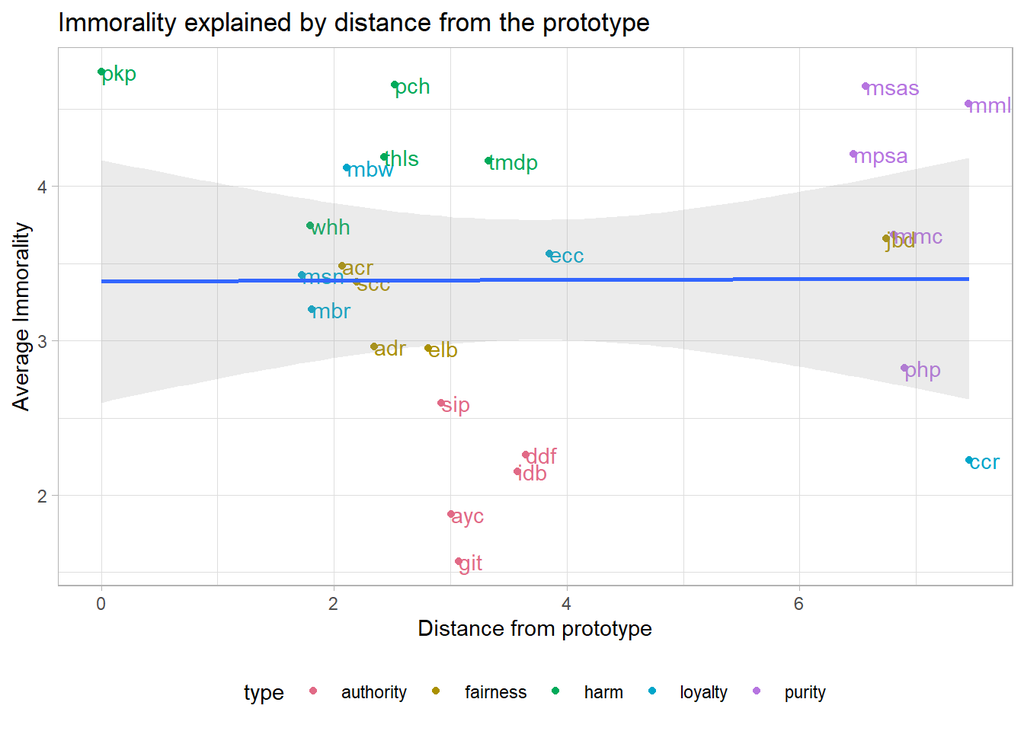

```r
# create mean measures from the long dataset

dsl <- d_long %>%
  group_by(scenario, type, def, dop, distances) %>%
  summarise(mean_harm = mean(harm),
            mean_imm = mean(immoral),
            mean_unex = mean(unexpected))

# Create a set of colors

types_color <- qualitative_hcl(5, palette = "Dark 3")

# Plot including all scenarios

dsl %>%
  ggplot(aes(x = distances, y = mean_imm, col = type)) +
  geom_point() +
  scale_color_manual(values = types_color) +
  geom_text(aes(label = scenario), hjust = 0, show.legend = F) +
  geom_smooth(inherit.aes = F, aes(x = distances, y = mean_imm), data = dsl, method = "lm", alpha = 0.2) + theme(legend.position = "bottom") +
  labs(x = "Distance from prototype",
       y = "Average Immorality",
       title = "Immorality explained by distance from the prototype")
```

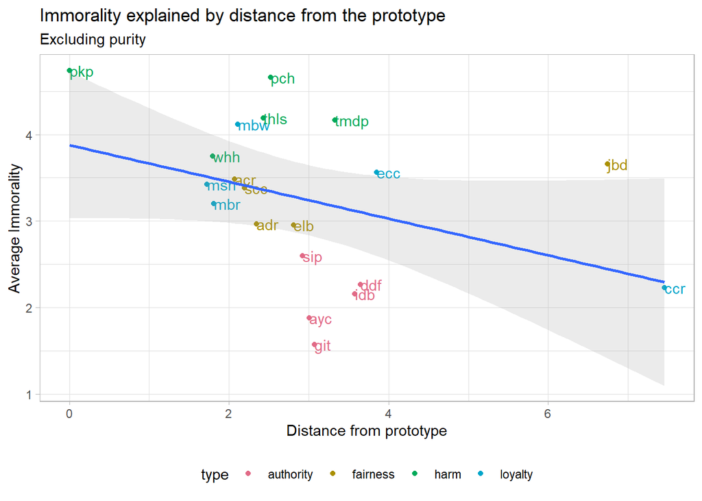

```r
# Plot exluding the purity scenarios

dsl %>%
  filter(type != 'purity') %>%
  ggplot(aes(x = distances, y = mean_imm, col = type)) +
  geom_point() +
  scale_color_manual(values = types_color) +
  geom_text(aes(label = scenario), hjust = 0, show.legend = F) +
  geom_smooth(inherit.aes = F, aes(x = distances, y = mean_imm), method = "lm", alpha = 0.2) + theme(legend.position = "bottom") +
  labs(x = "Distance from prototype",
       y = "Average Immorality",
       title = "Immorality explained by distance from the prototype",
       subtitle = "Excluding purity")
```

We see an interesting pattern here. In the plot that includes all scenarios, there seems to be no relationship between average immorality and distance from the prototype. When we exclude purity, however, the relationship becomes negative, as we would have expected. This is encouraging because it resonates with Kurt’s theory. As *most* trangressions move away from the template of the moral dyad, they become less immoral.

Nonetheless, there is an issue here: including the object’s potency in our calculations of distance could be misleading. As our previous analysis shows that increases in the object’s potency lead to decreases in the event’s severity. In this calculation, then, we are wrongly “penalizing” the scenarios that have more vulnerable patients than the one that features in our prototype - i.e. person -, which is fairly neutral. For that reason, I am going to calculate distance from the prototype, only considering the behavior’s evaluation and potency.

Let’s adjust the function and calculate the new distances:

```r
# Create new function

distance_two <- function( be, bp) {

   # Formula

  distance <- sqrt(((-4.26) - be)^2 + (1.95 - bp)^2)

  return(as.double(distance))
}

# Select the three axes we are interested in

events_values_2 <- events_def %>%
  select(scenario, be, bp)

# Create empty vector for the distances of all 25 events

distances_2 <- rep(0, 25)

# Loop for creating all 25 values

for (i in 1:25) {

d <- distance_two(
          be = events_values_2[i, 2],
          bp = events_values_2[i, 3])
  distances_2[[i]] <- d
}

# Column-bind the values to the events dataframe

events_values_2 <- events_values_2 %>%
  cbind(distances_2) %>%
  select(scenario, distances_2)


# Join values with the long dataset

d_long_two <- d_long %>%
  left_join(events_values_2, by = "scenario")

# create mean measures from the long dataset

dsl_two <- d_long_two %>%
  group_by(scenario, type, def, dop, distances_2) %>%
  summarise(mean_harm = mean(harm),
            mean_imm = mean(immoral),
            mean_unex = mean(unexpected))
```

Now, we can create the second set of summary plots:

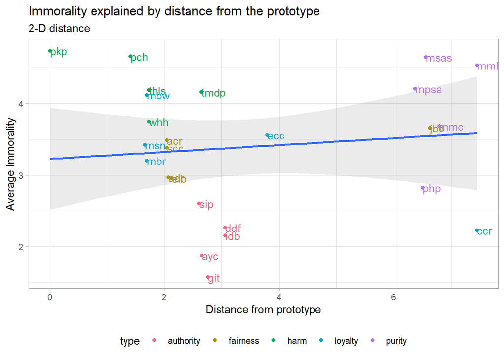

```r
# Create a set of colors

types_color <- qualitative_hcl(5, palette = "Dark 3")

# Plot including all scenarios

dsl_two %>%
  ggplot(aes(x = distances_2, y = mean_imm, col = type)) +
  geom_point() +
  scale_color_manual(values = types_color) +
  geom_text(aes(label = scenario), hjust = 0, show.legend = F) +
  geom_smooth(inherit.aes = F, aes(x = distances_2, y = mean_imm), data = dsl, method = "lm", alpha = 0.2) + theme(legend.position = "bottom") +
  labs(x = "Distance from prototype",
       y = "Average Immorality",
       title  = "Immorality explained by distance from the prototype",
       subtitle = "2-D distance")
```

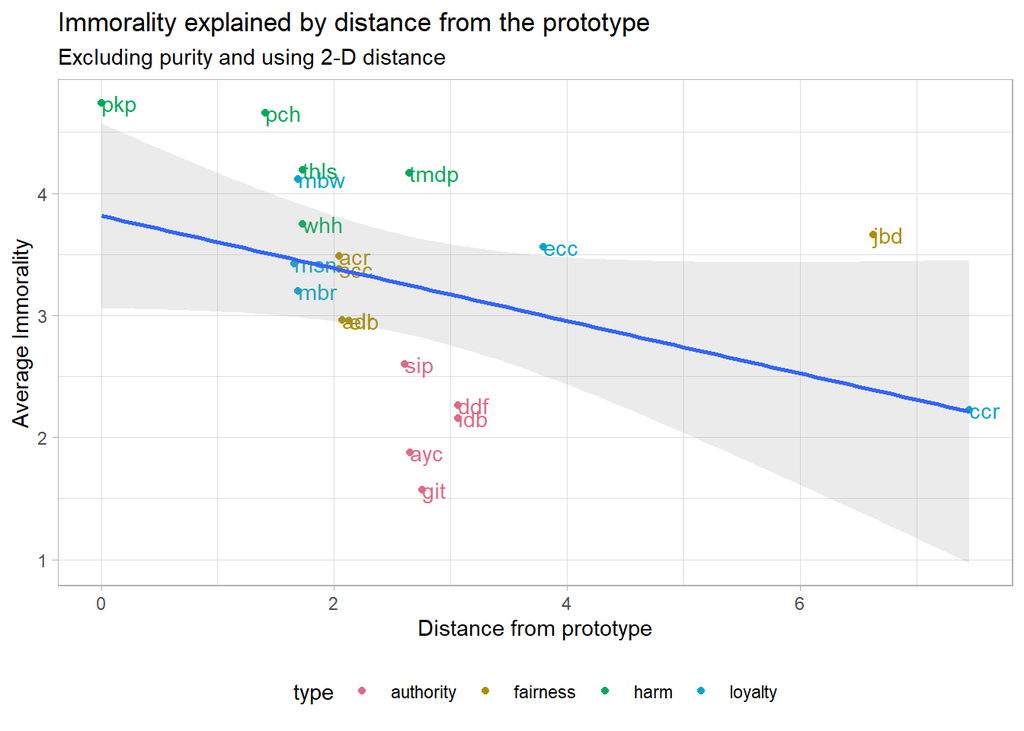

```r
# Plot exluding the purity scenarios

dsl_two %>%
  filter(type != 'purity') %>%
  ggplot(aes(x = distances_2, y = mean_imm, col = type)) +
  geom_point() +
  scale_color_manual(values = types_color) +
  geom_text(aes(label = scenario), hjust = 0, show.legend = F) +
  geom_smooth(inherit.aes = F, aes(x = distances_2, y = mean_imm), method = "lm", alpha = 0.2) + theme(legend.position = "bottom") +
  labs(x = "Distance from prototype",
       y = "Average Immorality",
       title  = "Immorality explained by distance from the prototype",
       subtitle = "Excluding purity and using 2-D distance")
```

The relationships are very similar to the ones above. When purity trangressions are excluded, distance from the prototype has a negative relationship with average immorality. Again, this echoes the predictions of the theory of dyadic morality.

## Differential Attribution of Harm

It is important to remember that if we conduct the reaction-time study, we would not necessarily be interested in the relationship between reaction time and severity (although we certainly will explore it). The argument is rather that distance from the prototype will be negatively related to reaction time. It is not, then, that events that are far away from the template are less severe - although that is probably the case - but that attributing harm and immorality to them is more cognitively difficult. This would help explain why we are fascinated by ‘purity’ trangressions, and perhaps why groups have found it necessary to construct such elaborate rules around them.